# Beliefs About Depression Study - Causal Belief LPA

2023-07-17

The primary aim of this study is to assess the relationship between causal beliefs for depression—as operationalized via latent profile analysis—and additional variables of interest.

- RQ 1: Which latent profiles of causal beliefs for depression best characterize this sample?
- RQ 2: Are causal beliefs (latent profile membership) associated with demographic characteristics?
- RQ 3: Are causal beliefs (latent profile membership) associated with psychological outcomes?
- Exploratory: Do the relationships in RQ 3 differ between those who meet versus do not meet clinical cutoffs for depression?

Pre-registration: https://osf.io/jx3pc

**Methodological Notes**

All data were imputed by missForest. The PFC (proportion falsely classified; equal to the proportion of *categorical* variables that missForest got wrong) was estimated to be 0.22. The NRMSE (normalized root mean squared error; in this case equal to the average error in predictions on the *numeric* variables, expressed in terms of standard deviations) was estimated to be 0.25. You can cite the missForest package when you report those statistics:

Stekhoven, D.J. and Buehlmann, P. (2012), ’MissForest - nonparametric missing value imputation for mixed-type data’, Bioinformatics, 28(1) 2012, 112-118, doi: 10.1093/bioinformatics/btr597

All *p*-values were adjusted to set the false discovery rate at .05. You can use this citation:

Benjamini, Y., & Hochberg, Y. (1995). Controlling the false discovery rate: a practical and powerful approach to multiple testing. Journal of the Royal statistical society: series B (Methodological), 57(1), 289-300.

## RQ 1: Which latent profiles of causal beliefs for depression best characterize this sample?

Here’s what we pre-registered: We will conduct a latent profile analysis using the ten RFD subscale mean scores as inputs. The latent profile analysis will be conducted using tidyLPA in R. We will assess a variety of latent profile models, with different numbers of profiles, variances set to be equal across groups or allowed to vary across groups, and covariances fixed to zero, set to equal across groups, or allowed to vary across groups. The optimal model will be selected based on examination of model fit statistics (e.g., BIC) and accounting for model parsimony and interpretability. The final model will be selected prior to further analyses (i.e., the decision of which model to use will not depend on the downstream effects of model selection on RQs 2 and 3).

Results:

We tried a variety of models with different numbers of classes and specifications. Ultimately the best model was one with three classes, variances allowed to be different across groups, and covariances fixed to zero.

### Figure 1. LPA

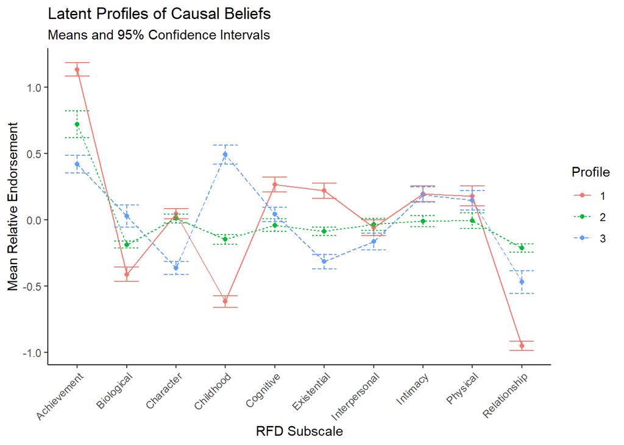

## RQ 2: Are causal beliefs (latent profile membership) associated with demographic characteristics?

For continuous demographic characteristics (age), we will conduct either a t-test (in the case of two latent profiles) or an ANOVA (in the case of more than two latent profiles) where group membership is the independent variable and the demographic characteristic is the dependent variable.

For categorical demographic characteristics (gender, race/ethnicity, family income), we will use a Chi-square test of independence to determine whether group membership depends on the demographic characteristic.

Results:

**Age.** There was a statistically significant difference in age across classes (F(2, 975) = 3.78, p(adj) = .028). Class 1 (mean = 18.91) was significantly younger than class 3 (mean = 19.16, p(adj) = .036).

| class | mean | se | lower_ci | upper_ci |
| --- | --- | --- | --- | --- |
| 1 | 18.91 | 0.06 | 18.80 | 19.02 |
| 2 | 18.88 | 0.11 | 18.66 | 19.10 |
| 3 | 19.16 | 0.08 | 19.00 | 19.32 |

```
##              Df Sum Sq Mean Sq F value Pr(>F)
## class         2   15.6   7.810   3.777 0.0232 *
## Residuals   975 2016.3   2.068
## ---
## Signif. codes:  0 '***' 0.001 '**' 0.01 '*' 0.05 '.' 0.1 ' ' 1
```

```
## # A tibble: 1 x 3
##   test          p_raw  p_adj
##   <chr>         <dbl>  <dbl>
## 1 age_by_class 0.0232 0.0284
```

```
##
##  Pairwise comparisons using t tests with pooled SD
##
## data:  df$age and df$class
##
##   1     2
## 2 0.831 -
## 3 0.036 0.084
##
## P value adjustment method: BH
```

**Gender.** There was a statistically significant difference in gender across classes (X^2(4) = 43.60, p(adj) < .001). Class 3 had a higher proportion of female students (73.73%) than class 1 (63.07%, p(adj) = .002) and class 2 (51.18%, p(adj) < .001). Class 1 had a higher proportion of female students than class 2 (p(adj) = .021). Class 2 had a higher proportion of male students (41.73%) than class 1 (29.59%, p(adj) = .014) and class 3 (15.66%, p(adj) < .001). Class 1 had a higher proportion of male students than class 3 (p(adj) < .001). There were no statistically significant differences in proportion trans/gender diverse students.

| class | gender | n | pct | se | lower_ci | upper_ci |
| --- | --- | --- | --- | --- | --- | --- |
| 1 | Cis Female | 275 | 63.07 | 1.69 | 59.76 | 66.39 |
| 1 | Cis Male | 129 | 29.59 | 2.47 | 24.75 | 34.43 |
| 1 | TGD | 32 | 7.34 | 4.96 | -2.38 | 17.06 |
| 2 | Cis Female | 65 | 51.18 | 2.88 | 45.54 | 56.83 |
| 2 | Cis Male | 53 | 41.73 | 3.19 | 35.48 | 47.98 |
| 2 | TGD | 9 | 7.09 | 7.74 | -8.08 | 22.25 |
| 3 | Cis Female | 306 | 73.73 | 2.01 | 69.80 | 77.67 |
| 3 | Cis Male | 65 | 15.66 | 4.35 | 7.13 | 24.19 |
| 3 | TGD | 44 | 10.60 | 5.29 | 0.24 | 20.97 |

```
##
##  Pearson's Chi-squared test
##
## data:  table(df$gender, df$class)
## X-squared = 43.595, df = 4, p-value = 7.785e-09
```

```
## # A tibble: 1 x 3
##   test                    p_raw        p_adj
##   <chr>                   <dbl>        <dbl>
## 1 gender_by_class 0.00000000779 0.0000000428
```

```
##
##  Pairwise comparisons using Pairwise comparison of proportions
##
## data:  table(df$class, df$gender == "Cis Female")
##
##   1      2
## 2 0.0210 -
## 3 0.0016 8.7e-06
##
## P value adjustment method: BH
```

```
##
##  Pairwise comparisons using Pairwise comparison of proportions
##
## data:  table(df$class, df$gender == "Cis Male")
##
##   1       2
## 2 0.014   -
## 3 2.9e-06 3.1e-09
##
## P value adjustment method: BH
```

```
##
##  Pairwise comparisons using Pairwise comparison of proportions
##
## data:  table(df$class, df$gender == "TGD")
##
##   1    2
## 2 1.00 -
## 3 0.36 0.48
##
## P value adjustment method: BH
```

| race_ethnicity | class | new_race | n | pct | se | lower_ci | upper_ci |
| --- | --- | --- | --- | --- | --- | --- | --- |
| Asian non-Hispanic | 1 | Asian non-Hispanic | 61 | 14.12 | 2.94 | 8.35 | 19.89 |
| Asian non-Hispanic | 2 | Asian non-Hispanic | 12 | 9.45 | 5.49 | -1.31 | 20.21 |
| Asian non-Hispanic | 3 | Asian non-Hispanic | 52 | 12.59 | 2.95 | 6.82 | 18.37 |
| Black non-Hispanic | 1 | Black non-Hispanic | 20 | 4.63 | 5.14 | -5.44 | 14.70 |
| Black non-Hispanic | 2 | Black non-Hispanic | 12 | 9.45 | 5.49 | -1.31 | 20.21 |
| Black non-Hispanic | 3 | Black non-Hispanic | 27 | 6.54 | 4.09 | -1.48 | 14.55 |
| Hispanic | 1 | Hispanic | 55 | 12.73 | 3.10 | 6.66 | 18.81 |
| Hispanic | 2 | Hispanic | 25 | 19.69 | 3.80 | 12.23 | 27.14 |
| Hispanic | 3 | Hispanic | 59 | 14.29 | 2.77 | 8.86 | 19.71 |
| ME/NA non-Hispanic | 1 | ME/NA non-Hispanic | 14 | 3.24 | 6.14 | -8.80 | 15.28 |
| ME/NA non-Hispanic | 2 | ME/NA non-Hispanic | 2 | 1.57 | 13.45 | -24.78 | 27.93 |
| ME/NA non-Hispanic | 3 | ME/NA non-Hispanic | 16 | 3.87 | 5.31 | -6.54 | 14.29 |
| Other or Multiracial non-Hispanic | 1 | Other or Multiracial non-Hispanic | 12 | 2.78 | 6.63 | -10.23 | 15.78 |
| Other or Multiracial non-Hispanic | 2 | Other or Multiracial non-Hispanic | 8 | 6.30 | 6.72 | -6.88 | 19.48 |
| Other or Multiracial non-Hispanic | 3 | Other or Multiracial non-Hispanic | 15 | 3.63 | 5.49 | -7.12 | 14.38 |
| White non-Hispanic | 1 | White non-Hispanic | 270 | 62.50 | 1.40 | 59.76 | 65.24 |
| White non-Hispanic | 2 | White non-Hispanic | 68 | 53.54 | 2.31 | 49.02 | 58.06 |
| White non-Hispanic | 3 | White non-Hispanic | 244 | 59.08 | 1.36 | 56.41 | 61.75 |

```
##
##  Pearson's Chi-squared test
##
## data:  table(race_data$new_race, race_data$class)
## X-squared = 15.378, df = 10, p-value = 0.1189
```

```
## # A tibble: 1 x 3
##   test          p_raw p_adj
##   <chr>         <dbl> <dbl>
## 1 race_by_class 0.119 0.131
```

**Family Income.** There was a statistically significant difference in family income across classes (X^2(2) = 16.92, p(adj) < .001). Class 1 had a significantly higher proportion of students whose family income was above the U.S. median (80.05%) than class 3 (67.95%, p(adj) < .001).

| class | family_income | n | pct | se | lower_ci | upper_ci |
| --- | --- | --- | --- | --- | --- | --- |
| 1 | Above U.S. Median | 349 | 80.05 | 2.27 | 75.59 | 84.50 |
| 1 | Below U.S. Median | 87 | 19.95 | 4.56 | 11.03 | 28.88 |
| 2 | Above U.S. Median | 98 | 77.17 | 3.88 | 69.56 | 84.77 |
| 2 | Below U.S. Median | 29 | 22.83 | 7.13 | 8.85 | 36.82 |
| 3 | Above U.S. Median | 282 | 67.95 | 1.51 | 64.99 | 70.91 |
| 3 | Below U.S. Median | 133 | 32.05 | 2.20 | 27.73 | 36.36 |

```
##
##  Pearson's Chi-squared test
##
## data:  table(df$family_income, df$class)
## X-squared = 16.917, df = 2, p-value = 0.0002121
```

```
## # A tibble: 1 x 3
##   test               p_raw    p_adj
##   <chr>              <dbl>    <dbl>
## 1 income_by_class 0.000212 0.000389
```

```
##
##  Pairwise comparisons using Pairwise comparison of proportions
##
## data:  table(df$class, df$family_income == "Above U.S. Median")
##
##   1       2
## 2 0.56081 -
## 3 0.00023 0.09140
##
## P value adjustment method: BH
```

### Table 1. Demographics Overall and by Profile

| Category | Value | Overall n | Overall pct | Profile 1 n | Profile 1 pct | Profile 2 n | Profile 2 pct | Profile 3 n | Profile 3 pct |
| --- | --- | --- | --- | --- | --- | --- | --- | --- | --- |
| family_income | Above U.S. Median | 729 | 75% | 349 | 80% | 98 | 77% | 282 | 68% |
| family_income | Below U.S. Median | 249 | 25% | 87 | 20% | 29 | 23% | 133 | 32% |
| gender | Cis Female | 646 | 66% | 275 | 63% | 65 | 51.2% | 306 | 73.7% |
| gender | Cis Male | 247 | 25% | 129 | 30% | 53 | 41.7% | 65 | 15.7% |
| gender | TGD | 85 | 9% | 32 | 7% | 9 | 7.1% | 44 | 10.6% |
| race_ethnicity | AI/AN non-Hispanic | 4 | 0.41% | 3 | 0.69% | NA | NA | 1 | 0.24% |
| race_ethnicity | Asian non-Hispanic | 125 | 12.78% | 61 | 13.99% | 12 | 9.4% | 52 | 12.53% |
| race_ethnicity | Black non-Hispanic | 59 | 6.03% | 20 | 4.59% | 12 | 9.4% | 27 | 6.51% |
| race_ethnicity | Hispanic | 139 | 14.21% | 55 | 12.61% | 25 | 19.7% | 59 | 14.22% |
| race_ethnicity | ME/NA non-Hispanic | 32 | 3.27% | 14 | 3.21% | 2 | 1.6% | 16 | 3.86% |
| race_ethnicity | NH/PI non-Hispanic | 2 | 0.20% | 1 | 0.23% | NA | NA | 1 | 0.24% |
| race_ethnicity | Other or Multiracial non-Hispanic | 35 | 3.58% | 12 | 2.75% | 8 | 6.3% | 15 | 3.61% |
| race_ethnicity | White non-Hispanic | 582 | 59.51% | 270 | 61.93% | 68 | 53.5% | 244 | 58.80% |

|  | Overall mean | Overall sd | Profile 1 mean | Profile 1 sd | Profile 2 mean | Profile 2 sd | Profile 3 mean | Profile 3 sd |
| --- | --- | --- | --- | --- | --- | --- | --- | --- |
| Age | 19.01404 | 1.442121 | 18.91284 | 1.188729 | 18.88189 | 1.251121 | 19.1608 | 1.705591 |

## RQ 3: How do causal beliefs (latent profile membership) relate to psychological outcomes?

We will conduct either t-tests (in the case of two latent profiles) or ANOVAs (in the case of more than two latent profiles) where group membership is the independent variable and the psychological outcomes are dependent variables.

Results:

**Prognostic Pessimism.** There was a statistically significant difference in prognostic pessimism across classes (F(2, 975) = 24.89, p(adj) < .001). The mean of prognostic pessimism was significantly higher in class 3 than in class 1 (p(adj) < .001) and class 2 (p(adj) < .001). The mean of prognostic pessimism was significantly higher in class 1 than in class 2 (p(adj) < .001).

| class | mean | se | lower_ci | upper_ci |
| --- | --- | --- | --- | --- |
| 1 | -0.08 | 0.04 | -0.16 | 0.01 |
| 2 | -0.45 | 0.09 | -0.61 | -0.28 |
| 3 | 0.22 | 0.05 | 0.12 | 0.32 |

```
##              Df Sum Sq Mean Sq F value   Pr(>F)
## class         2   47.5  23.729   24.89 2.87e-11 ***
## Residuals   975  929.5   0.953
## ---
## Signif. codes:  0 '***' 0.001 '**' 0.01 '*' 0.05 '.' 0.1 ' ' 1
```

```
## # A tibble: 1 x 3
##   test                             p_raw    p_adj
##   <chr>                            <dbl>    <dbl>
## 1 prognostic_pessimism_by_class 2.87e-11 3.15e-10
```

```
##
##  Pairwise comparisons using t tests with pooled SD
##
## data:  df$prognostic_pessimism and df$class
##
##   1       2
## 2 2e-04   -
## 3 1.7e-05 1.1e-10
##
## P value adjustment method: BH
```

**Blame.** There was a statistically significant difference in blame across classes (F(2, 975) = 16.45, p(adj) < .001). The mean of blame was significantly higher in class 1 than in class 2 (p(adj) < .001) and class 3 (p(adj) < .001).

| class | mean | se | lower_ci | upper_ci |
| --- | --- | --- | --- | --- |
| 1 | 0.19 | 0.05 | 0.10 | 0.28 |
| 2 | -0.30 | 0.09 | -0.47 | -0.13 |
| 3 | -0.11 | 0.05 | -0.20 | -0.01 |

```
##              Df Sum Sq Mean Sq F value   Pr(>F)
## class         2   31.9  15.942   16.45 9.45e-08 ***
## Residuals   975  945.1   0.969
## ---
## Signif. codes:  0 '***' 0.001 '**' 0.01 '*' 0.05 '.' 0.1 ' ' 1
```

```
## # A tibble: 1 x 3
##   test                  p_raw       p_adj
##   <chr>                 <dbl>       <dbl>
## 1 blame_by_class 0.0000000945 0.000000346
```

```
##
##  Pairwise comparisons using t tests with pooled SD
##
## data:  df$blame and df$class
##
##   1       2
## 2 3.2e-06 -
## 3 1.6e-05 0.059
##
## P value adjustment method: BH
```

**Agency.** There was a statistically significant difference in agency across classes (F(2, 975) = 4.72, p(adj) = .013). The means of agency in both class 1 (p(adj) = .038) and class 2 (p(adj) = .018) were higher than in class 3.

| class | mean | se | lower_ci | upper_ci |
| --- | --- | --- | --- | --- |
| 1 | 0.05 | 0.04 | -0.04 | 0.14 |
| 2 | 0.17 | 0.09 | 0.00 | 0.35 |
| 3 | -0.10 | 0.05 | -0.21 | 0.00 |

```
##              Df Sum Sq Mean Sq F value  Pr(>F)
## class         2    9.4   4.687   4.723 0.00909 **
## Residuals   975  967.6   0.992
## ---
## Signif. codes:  0 '***' 0.001 '**' 0.01 '*' 0.05 '.' 0.1 ' ' 1
```

```
## # A tibble: 1 x 3
##   test              p_raw  p_adj
##   <chr>             <dbl>  <dbl>
## 1 agency_by_class 0.00909 0.0125
```

```
##
##  Pairwise comparisons using t tests with pooled SD
##
## data:  df$agency and df$class
##
##   1     2
## 2 0.214 -
## 3 0.038 0.018
##
## P value adjustment method: BH
```

**Stigma.** There was a statistically significant difference in stigma across classes (F(2, 975) = 8.652, p(adj) < .001). Stigma was higher for class 2 than for class 1 (p(adj) = .008) and class 3 (p(adj) < .001). Stigma was higher for class 1 than for class 3 (p(adj) = .049).

| class | mean | se | lower_ci | upper_ci |
| --- | --- | --- | --- | --- |
| 1 | 0.02 | 0.05 | -0.07 | 0.12 |
| 2 | 0.30 | 0.09 | 0.11 | 0.49 |
| 3 | -0.11 | 0.05 | -0.20 | -0.02 |

```
##              Df Sum Sq Mean Sq F value   Pr(>F)
## class         2     17   8.518   8.652 0.000189 ***
## Residuals   975    960   0.985
## ---
## Signif. codes:  0 '***' 0.001 '**' 0.01 '*' 0.05 '.' 0.1 ' ' 1
```

```
## # A tibble: 1 x 3
##   test               p_raw    p_adj
##   <chr>              <dbl>    <dbl>
## 1 stigma_by_class 0.000189 0.000389
```

```
##
##  Pairwise comparisons using t tests with pooled SD
##
## data:  df$stigma and df$class
##
##   1       2
## 2 0.00784 -
## 3 0.04858 0.00012
##
## P value adjustment method: BH
```

| class | mean | se | lower_ci | upper_ci |
| --- | --- | --- | --- | --- |
| 1 | 0.04 | 0.05 | -0.05 | 0.13 |
| 2 | 0.09 | 0.07 | -0.05 | 0.23 |
| 3 | -0.07 | 0.05 | -0.18 | 0.03 |

```
##              Df Sum Sq Mean Sq F value Pr(>F)
## class         2    3.8  1.9236   1.927  0.146
## Residuals   975  973.2  0.9981
```

```
## # A tibble: 1 x 3
##   test                      p_raw p_adj
##   <chr>                     <dbl> <dbl>
## 1 function_beliefs_by_class 0.146 0.146
```

**Attitudes Towards Therapy.** There was a statistically significant difference in attitudes towards therapy across classes (F(2, 975) = 8.93, p(adj) < .001). Class 3 had significantly higher scores than class 1 (p(adj) < .001).

| class | mean | se | lower_ci | upper_ci |
| --- | --- | --- | --- | --- |
| 1 | -0.13 | 0.05 | -0.23 | -0.03 |
| 2 | -0.05 | 0.09 | -0.22 | 0.12 |
| 3 | 0.15 | 0.04 | 0.07 | 0.24 |

```
##              Df Sum Sq Mean Sq F value   Pr(>F)
## class         2   17.6   8.790   8.933 0.000143 ***
## Residuals   975  959.4   0.984
## ---
## Signif. codes:  0 '***' 0.001 '**' 0.01 '*' 0.05 '.' 0.1 ' ' 1
```

```
## # A tibble: 1 x 3
##   test                          p_raw    p_adj
##   <chr>                         <dbl>    <dbl>
## 1 therapy_attitudes_by_class 0.000143 0.000389
```

```
##
##  Pairwise comparisons using t tests with pooled SD
##
## data:  df$MHSAS_therapy and df$class
##
##   1       2
## 2 0.414   -
## 3 9.4e-05 0.066
##
## P value adjustment method: BH
```

**Attitudes Towards Medication.** There was a statistically significant difference in attitudes towards medication across classes (F(2, 975) = 7.28, p(adj) = .001). Class 3 had significantly higher scores than class 1 (p(adj) = .003) and class 2 (p(adj) = .006).

| class | mean | se | lower_ci | upper_ci |
| --- | --- | --- | --- | --- |
| 1 | -0.09 | 0.05 | -0.18 | 0.00 |
| 2 | -0.15 | 0.09 | -0.33 | 0.03 |
| 3 | 0.14 | 0.05 | 0.04 | 0.23 |

```
##              Df Sum Sq Mean Sq F value  Pr(>F)
## class         2   14.4   7.184   7.277 0.00073 ***
## Residuals   975  962.6   0.987
## ---
## Signif. codes:  0 '***' 0.001 '**' 0.01 '*' 0.05 '.' 0.1 ' ' 1
```

```
## # A tibble: 1 x 3
##   test                             p_raw   p_adj
##   <chr>                            <dbl>   <dbl>
## 1 medication_attitudes_by_class 0.000730 0.00115
```

```
##
##  Pairwise comparisons using t tests with pooled SD
##
## data:  df$MHSAS_medication and df$class
##
##   1      2
## 2 0.5444 -
## 3 0.0025 0.0063
##
## P value adjustment method: BH
```

### Figure 2. Psychological Outcomes by Profile

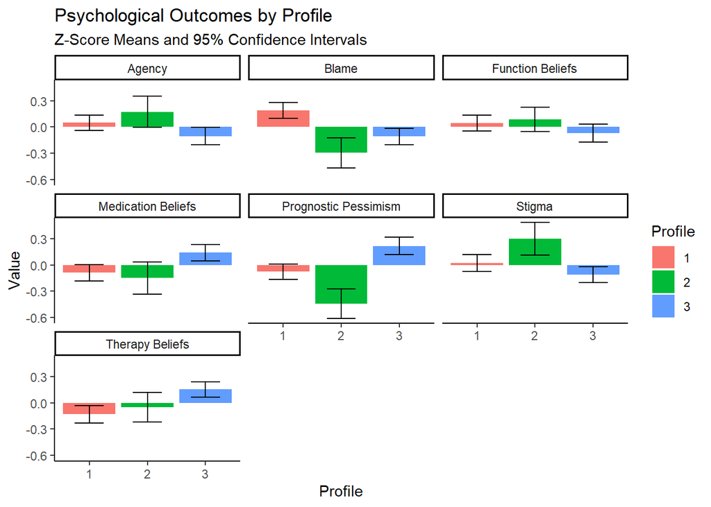

## Exploratory: Do the relationships in RQ 3 differ between those who meet versus do not meet clinical cutoffs for depression?

This will be assessed via two-way ANOVAs, identical to those in RQ 3 but with depression status as an additional independent variable. In this case, we are interested in the interaction term; the statistic that indicates whether the relationship between profile membership and outcome (RQ 3) depends on depression status.

```
##                    Df Sum Sq Mean Sq F value   Pr(>F)
## class               2   47.5   23.73  26.139 8.76e-12 ***
## PHQ8_cutoff         1   37.1   37.13  40.904 2.48e-10 ***
## class:PHQ8_cutoff   2   10.0    5.02   5.529   0.0041 **
## Residuals         972  882.4    0.91
## ---
## Signif. codes:  0 '***' 0.001 '**' 0.01 '*' 0.05 '.' 0.1 ' ' 1
```

```
##                    Df Sum Sq Mean Sq F value   Pr(>F)
## class               2   31.9  15.942  16.481 9.14e-08 ***
## PHQ8_cutoff         1    2.8   2.807   2.902   0.0888 .
## class:PHQ8_cutoff   2    2.1   1.061   1.097   0.3345
## Residuals         972  940.2   0.967
## ---
## Signif. codes:  0 '***' 0.001 '**' 0.01 '*' 0.05 '.' 0.1 ' ' 1
```

```
##                    Df Sum Sq Mean Sq F value   Pr(>F)
## class               2    9.4    4.69   4.945   0.0073 **
## PHQ8_cutoff         1   43.7   43.70  46.109 1.94e-11 ***
## class:PHQ8_cutoff   2    2.6    1.32   1.394   0.2485
## Residuals         972  921.3    0.95
## ---
## Signif. codes:  0 '***' 0.001 '**' 0.01 '*' 0.05 '.' 0.1 ' ' 1
```

```
##                    Df Sum Sq Mean Sq F value  Pr(>F)
## class               2   17.0   8.518   8.644 0.00019 ***
## PHQ8_cutoff         1    0.3   0.274   0.278 0.59805
## class:PHQ8_cutoff   2    1.8   0.925   0.938 0.39157
## Residuals         972  957.8   0.985
## ---
## Signif. codes:  0 '***' 0.001 '**' 0.01 '*' 0.05 '.' 0.1 ' ' 1
```

```
##                    Df Sum Sq Mean Sq F value Pr(>F)
## class               2    3.8   1.924   1.931 0.1456
## PHQ8_cutoff         1    4.6   4.628   4.646 0.0314 *
## class:PHQ8_cutoff   2    0.1   0.063   0.063 0.9388
## Residuals         972  968.4   0.996
## ---
## Signif. codes:  0 '***' 0.001 '**' 0.01 '*' 0.05 '.' 0.1 ' ' 1
```

```
##                    Df Sum Sq Mean Sq F value   Pr(>F)
## class               2   17.6   8.790   8.908 0.000147 ***
## PHQ8_cutoff         1    0.2   0.165   0.167 0.683010
## class:PHQ8_cutoff   2    0.1   0.069   0.070 0.932734
## Residuals         972  959.1   0.987
## ---
## Signif. codes:  0 '***' 0.001 '**' 0.01 '*' 0.05 '.' 0.1 ' ' 1
```

```
##                    Df Sum Sq Mean Sq F value   Pr(>F)
## class               2   14.4   7.184   7.283 0.000725 ***
## PHQ8_cutoff         1    3.7   3.650   3.700 0.054694 .
## class:PHQ8_cutoff   2    0.1   0.059   0.060 0.941542
## Residuals         972  958.9   0.986
## ---
## Signif. codes:  0 '***' 0.001 '**' 0.01 '*' 0.05 '.' 0.1 ' ' 1
```

Results: There was a statistically significant interaction between class and depression status on prognostic pessimism only.

Across the board, people meeting the clinical cutoff for depression experienced greater prognostic pessimism (p < .001). Prognostic pessimism was also different across classes regardless of depression status (p < .001). There was a significant interaction, where the relationship between class and prognostic pessimism depended on depression status (p = .004). From visual inspection, we can see that prognostic pessimism was especially high among people who met criteria *and* were in class 3.

### Figure 3. Interaction

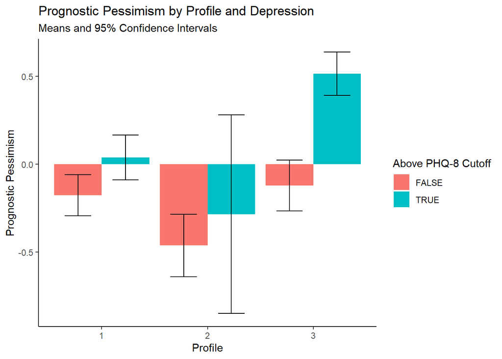